# Offensive Contribution Prediction Model of Players Based on La Liga 2023/2024 Season

Author

Jingwei Chen

Categorizing or changing our data.

According to our orinigal csv document, we would like to combine the data of “shots_off_target_inc_woodwork”

and “shots_on_target_inc_goals” together to form a new variable “shots”.

```r
soccer <- soccer |>
    mutate(shots = shots_off_target_inc_woodwork + shots_on_target_inc_goals)
```

We also have to filter out those players who have no goals thorought the season, because factors like

injury and special position (GK specifically) will have a dramatic impact to our goal prediction model.

```r
soccer <- soccer |>
    filter(goals > 0)
```

Now, we take a look at the graph.

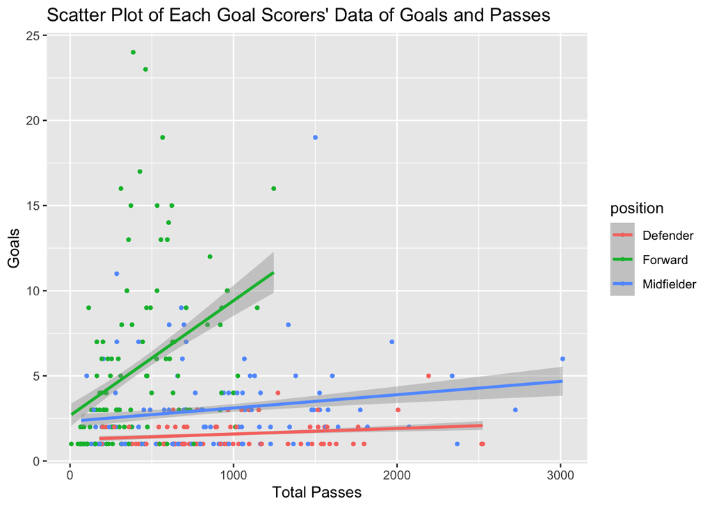

Some elements inside the regression line.

Let’s predict by randomly choosing a player from La Liga.

Checking our goal prediction number with the real goal number.

Multiple Regression Line Expression.

To form a regression line, we have to consider what are some important factors that would potentially contribute to a goal:

· Total Passes

· Successful Dribbles

· Corners Won

· Penalties Taken

· Shots

```r
model <- lm(goals ~ total_passes + successful_dribbles + corners_won + penalties_taken + shots, data = soccer)
model
```

```
Call:
lm(formula = goals ~ total_passes + successful_dribbles + corners_won +
    penalties_taken + shots, data = soccer)

Coefficients:
        (Intercept)         total_passes  successful_dribbles
          -0.860570            -0.001295             0.008045
        corners_won      penalties_taken                shots
          -0.078516             1.025462             0.205220
```

Given that, in La Liga 2023/2024 season, the player Artem Dovbyk has a data of 386 total passes, 17 successful dribbles,

12 corners won, 8 penalties taken, and 77 shots, we can predict his total season goal by importing these data into our

goal prediction model.

```r
data <- data.frame(total_passes = 386,
                   successful_dribbles = 17,
                   corners_won = 12,
                   penalties_taken = 8,
                   shots = 77)
```

```r
predict(model, data)
```

```
       1
21.83962
```

So, the predicted goals is 21.8396183, which is approximately 22 goals, and let’s reveal the Artem Dovbyk’s real goals:

```r
soccer$goals[soccer$name == "Artem Dovbyk"][1]
```

```
[1] 24
```

We have a residual of only 2 goals; this indicates that the selected offensive variables capture a substantial portion of the player’s scoring performance.

Expected Goals = - 0.860570 - 0.001295 * Total Passes + 0.008045 * Successful Dribbles - 0.078516 * Corners Won + 1.025462 * Penalties Taken + 0.205220 * Shots